# Demo 7 — Mapping Color Patterns onto a Phylogeny

EEB 187: Ecology and Evolution of Color

Published

May 20, 2026

**Patched 2026-05-22 — re-run with the new FishView bundle**

The FishView bundle exporter has been fixed. The patched bundle now ships a tree pruned to your picked species (no outgroups), cleaned tip labels, and a working `README.txt`. **If you ran Demo 7 before May 22, please re-export your bundle from FishView and re-run this worksheet from Step 1.** The full re-run + lock-and-load instructions are in the [Project Recipe Book launch announcement on BruinLearn](https://bruinlearn.ucla.edu/courses/228629/discussion_topics).

## Introduction

Today you are going to do something that most biologists only encounter in graduate school: map traits onto a phylogenetic tree and ask whether evolutionary history predicts what organisms look like. Specifically, you will take a dataset of color pattern traits for surgeonfishes (family Acanthuridae) and a time-calibrated phylogeny, and combine them to ask: **are closely related surgeonfishes more similar in their color patterns than you would expect by chance?**

This question sits at the heart of comparative biology. If you know that two species are close relatives, can you predict that they share similar color patterns? Or do color patterns evolve so rapidly — driven by selection for camouflage, mate recognition, or species identity — that relatedness tells you almost nothing? The statistical tools we will use today, **Blomberg’s K** and **Pagel’s lambda**, give us a rigorous way to answer this. These metrics measure what comparative biologists call **phylogenetic signal**: the degree to which the phylogeny predicts trait similarity among species.

Don’t worry if this feels new. The code is all written for you — your job is to run it, look at the output, and think hard about what it means. By the end of class, you will be able to load a phylogeny, match it to trait data, visualize traits on a tree, and test for phylogenetic signal. Later today, in **Part 2**, you’ll apply these methods to your group’s own fish clade using images you pick on the FishView server.

## Setup

Before we begin, we need to load two R packages: `ape` (for reading and manipulating phylogenies) and `phytools` (for trait mapping and signal tests).

**First time? Install the packages first**

If you have never used these packages before, run this line **once** in your R console:

```r
install.packages(c("ape", "phytools"))
```

You only need to do this once per computer. After that, you just load them with `library()`.

```r
library(ape)       # reading and manipulating phylogenetic trees
library(phytools)  # trait mapping, contMap, phylogenetic signal tests
```

Now set your working directory to the folder that contains the `data/` subfolder. **This path will be different on your computer** — adjust it to wherever you saved the demo materials.

```r
# Change this path to match YOUR computer!
setwd("~/Desktop/demo7/")
```

Now create a folder to hold the figures you will generate today. Every plot in this worksheet will get saved to this folder as a PDF, so by the end of class you will have a tidy archive of your results.

```r
# Create a results folder if it doesn't exist
if (!dir.exists("results")) dir.create("results")
```

**Why save PDFs?**

When you view a plot in RStudio’s Plots pane, you are seeing a rasterized preview — it can look fuzzy or even drop thin lines if the pane is small. Saving to **PDF** writes vector graphics that stay sharp at any zoom level and that you can open, print, or include in a poster without losing quality.

You will see the same three-line pattern after every plot in this worksheet:

```r
pdf("results/something.pdf", width = 10, height = 8)  # open a PDF device
plot(...)                                              # redraw the plot
dev.off()                                              # close the device
```

The PDF is only written when `dev.off()` runs. If you forget that line, R will hold the file open and the PDF will be empty or corrupted.

## Section 1: Loading and Plotting the Tree

Our phylogeny comes from Frederich et al., who built a time-calibrated tree for surgeonfishes. “Time-calibrated” means the branch lengths are in **millions of years** — so you can read off approximately when lineages diverged.

Let’s load it and take a look.

```r
tree <- read.nexus("data/frederich/acanthuridae-tree.tree")

# What did we just load?
tree
```

```
Phylogenetic tree with 65 tips and 64 internal nodes.

Tip labels:
  Acanthurus_achilles, Acanthurus_auranticavus, Acanthurus_bahianus, Acanthurus_bariene, Acanthurus_blochii, Acanthurus_chirurgus, ...

Rooted; includes branch length(s).
```

```r
cat("Number of tips (species):", length(tree$tip.label), "\n")
```

```
Number of tips (species): 65
```

```r
cat("Root age:", round(max(branching.times(tree)), 1), "million years\n")
```

```
Root age: 65.3 million years
```

```r
# What genera are represented?
genera <- unique(sub("_.*", "", tree$tip.label))
cat("Genera:", paste(genera, collapse = ", "), "\n")
```

```
Genera: Acanthurus, Ctenochaetus, Luvarus, Naso, Paracanthurus, Prionurus, Zanclus, Zebrasoma
```

You should see 65 species and a root age of about 65 million years — right around the end-Cretaceous mass extinction. The major genera are **Acanthurus** (the largest), **Naso** (unicornfishes), **Zebrasoma** (tangs), **Ctenochaetus** (bristletooths), **Prionurus**, and **Paracanthurus** (that’s Dory).

Now let’s visualize it. First a rectangular tree, then a fan layout that fits better on screen.

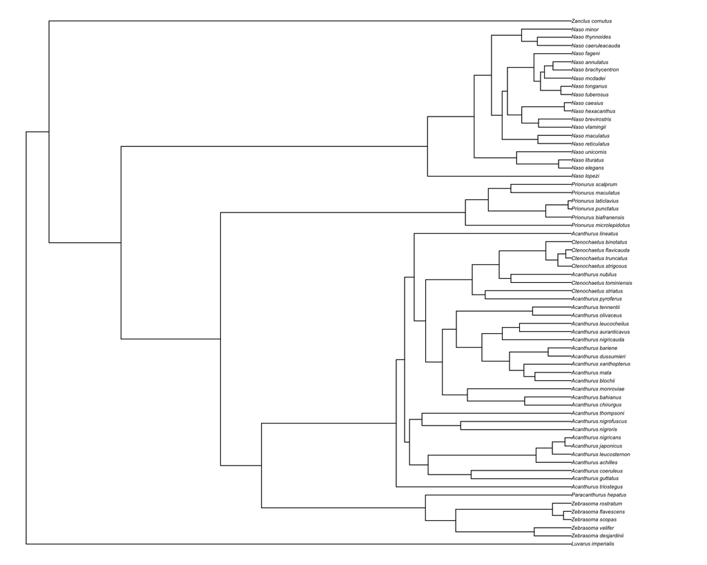

```r
plot(tree, cex = 0.45, no.margin = TRUE)
```

Save a PDF of the rectangular tree to your results folder:

```r
pdf("results/acanthuridae-tree-rectangular.pdf", width = 10, height = 8)
plot(tree, cex = 0.45, no.margin = TRUE)
dev.off()
```

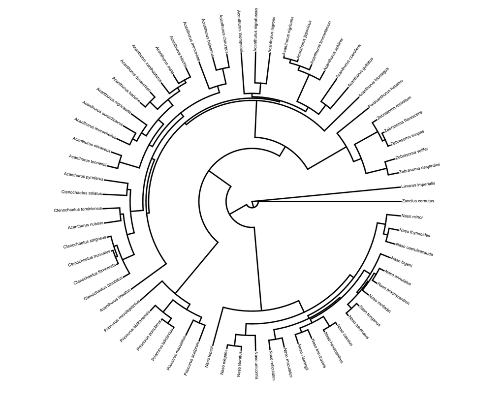

```r
plotTree(tree, type = "fan", fsize = 0.5, lwd = 2.5)
```

**If the fan tree looks empty or has only a few visible branches**

The RStudio Plots pane can render thin lines at sub-pixel widths, which makes some branches disappear. If your fan tree looks mostly blank with only a couple of long branches visible (those go to the outgroups *Luvarus* and *Zanclus*), try one of these fixes:

1. **Maximize the Plots pane** before re-running the chunk (or drag its corner to make it bigger and roughly square).
2. **Open the saved PDF** (next chunk) — the PDF version always renders correctly because it uses vector graphics.
3. **Bump `lwd`** higher (e.g., `lwd = 3` or `lwd = 4`) to force thicker lines.

Save a PDF of the fan tree:

```r
pdf("results/acanthuridae-tree-fan.pdf", width = 10, height = 10)
plotTree(tree, type = "fan", fsize = 0.5, lwd = 2.5)
dev.off()
```

**Take a moment.** Open `results/acanthuridae-tree-fan.pdf` and zoom in. Can you spot where the major genera are? *Acanthurus* is the biggest cluster. *Naso* (unicornfishes) should be a distinct clade. *Zebrasoma* species cluster together. See if you can find Paracanthurus — the only species in its genus.

## Section 2: Loading Color Pattern Data

Frederich et al. scored 52 binary color-pattern traits for 83 surgeonfish species. Each trait records whether a specific pattern element is **present (1)** or **absent (0)** on a particular body region.

```r
traits <- read.csv("data/frederich/acanthuridae-color-patterns.csv",
                    stringsAsFactors = FALSE, check.names = FALSE)

cat("Species in dataset:", nrow(traits), "\n")
```

```
Species in dataset: 83
```

```r
cat("Total columns:", ncol(traits), "\n")
```

```
Total columns: 59
```

**What do those column names mean?**

The trait columns use a prefix coding system based on body region:

| Prefix | Body region | Examples |
| --- | --- | --- |
| **H_** | Head | `H_marbling`, `H_1_v_strip`, `H_eyespot` |
| **Tr_** | Trunk (body) | `Tr_1_h_strip`, `Tr_marbling`, `Tr_eyespot` |
| **Ta_** | Tail | `Ta_saddle`, `Ta_colored_scalpel`, `Ta_eyespot` |

So `Tr_marbling` means “irregular worm-like markings on the trunk” and `Ta_colored_scalpel` means “the caudal spine (the surgeonfish’s famous tail blade) is distinctly colored.”

The first 7 columns are metadata: a row number, the species name, and five biogeographic region codes (CIP, WI, CP, A, TEP). The pattern traits start at column 8.

Let’s peek at the column names to confirm:

```r
names(traits)
```

```
 [1] "#"                         "species"
 [3] "CIP"                       "WI"
 [5] "CP"                        "A"
 [7] "TEP"                       "H_1_color"
 [9] "H_2_colors_+"              "H_colorful_mouth"
[11] "H_1_h_strip"               "H_2_h_strips_+"
[13] "H_1_v_strip"               "H_2_v_strips_+"
[15] "H_1_o_strip"               "H_2_o_strips_+"
[17] "H_1_stain"                 "H_2_stains_+"
[19] "H_1_point"                 "H_2_points_+"
[21] "H_eyespot"                 "H_h_strip_eye"
[23] "H_v_strip_eye"             "H_stain_eye"
[25] "H_circle_eye"              "H_marbling"
[27] "H_beehive_pattern"         "H_edge_operculum"
[29] "Tr_1_color"                "Tr_2_colors_+"
[31] "Tr_1_h_strip"              "Tr_2_h_strips_+"
[33] "Tr_1_v_strip"              "Tr_2_v_strips_+"
[35] "Tr_1_stain"                "Tr_2_stains_+"
[37] "Tr_1_point"                "Tr_2_points_+"
[39] "Tr_marbling"               "Tr_beehive_pattern"
[41] "Tr_eyespot"                "Tr_spot_base_fin_pectoral"
[43] "Ta_1_color"                "Ta_2_color_+"
[45] "Ta_1_strip_h"              "Ta_2_strips_h_+"
[47] "Ta_1_strip_v"              "Ta_2_strips_v_+"
[49] "Ta_1_stain"                "Ta_2_stains_+"
[51] "Ta_1_point"                "Ta_2_points_+"
[53] "Ta_marbling"               "Ta_beehive_pattern"
[55] "Ta_eyespot"                "Ta_saddle"
[57] "Ta_colored_scalpel"        "Ta_stain_scalpel"
[59] "Ta_border_fin"
```

## Section 3: Matching Tree to Data

Here is the **golden rule** of comparative phylogenetics:

**The Golden Rule**

**The species in your tree and the species in your data must match exactly.** Every species in your analysis needs to appear in both the tree and the trait table. Species that are in one but not the other get dropped.

This sounds obvious, but it is the single most common source of errors in comparative analyses. Names must match *exactly* — `Acanthurus_achilles` is not the same as `Acanthurus achilles` or `A. achilles`.

Let’s check the overlap:

```r
overlap <- intersect(tree$tip.label, traits$species)
cat("Species in BOTH tree and data:", length(overlap), "\n")
```

```
Species in BOTH tree and data: 62
```

```r
cat("In tree but NOT in data:      ", length(setdiff(tree$tip.label, traits$species)), "\n")
```

```
In tree but NOT in data:       3
```

```r
cat("In data but NOT in tree:      ", length(setdiff(traits$species, tree$tip.label)), "\n")
```

```
In data but NOT in tree:       21
```

We have 62 species in common. That means 3 species are in the tree but lack color data, and 21 species have color data but are not in the tree. This is completely normal — real datasets *never* have perfect overlap.

Now we prune the tree and filter the data so they match:

```r
# Prune the tree to keep only species with data
tree_matched <- drop.tip(tree, setdiff(tree$tip.label, overlap))
cat("Matched tree:", length(tree_matched$tip.label), "tips\n")
```

```
Matched tree: 62 tips
```

```r
# Filter the trait table to keep only species in the tree
tr <- traits[traits$species %in% overlap, ]
cat("Matched data:", nrow(tr), "rows\n")
```

```
Matched data: 62 rows
```

From here on, `tree_matched` and `tr` are our working objects. They have exactly the same 62 species.

## Section 4: Pattern Complexity

Before we look at individual traits, let’s create a **summary variable**: how many total color pattern elements does each species have? This is a rough measure of how “visually complex” a surgeonfish is. A species with 18 pattern elements has stripes, spots, marbling, and eyespots all over its body. A species with 4 elements is relatively plain.

```r
# Sum all binary pattern traits (columns 8 onward)
pattern_cols <- names(tr)[8:ncol(tr)]
tr$pattern_complexity <- rowSums(tr[, pattern_cols], na.rm = TRUE)

# Who's most complex? Who's simplest?
cat("Most complex:", tr$species[which.max(tr$pattern_complexity)],
    "—", max(tr$pattern_complexity), "elements\n")
```

```
Most complex: Acanthurus_bariene — 19 elements
```

```r
cat("Simplest:    ", tr$species[which.min(tr$pattern_complexity)],
    "—", min(tr$pattern_complexity), "elements\n")
```

```
Simplest:     Zebrasoma_rostratum — 4 elements
```

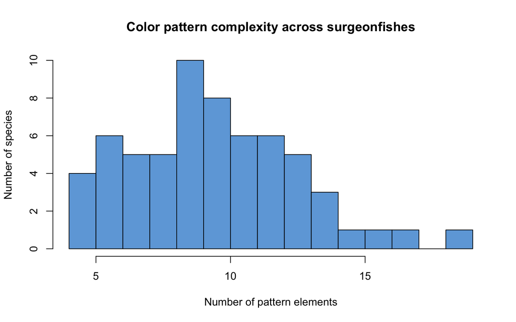

```r
hist(tr$pattern_complexity, breaks = 12, col = "#6fa8dc",
     main = "Color pattern complexity across surgeonfishes",
     xlab = "Number of pattern elements", ylab = "Number of species")
```

Save a PDF copy of the histogram:

```r
pdf("results/pattern-complexity-histogram.pdf", width = 8, height = 5)
hist(tr$pattern_complexity, breaks = 12, col = "#6fa8dc",
     main = "Color pattern complexity across surgeonfishes",
     xlab = "Number of pattern elements", ylab = "Number of species")
dev.off()
```

Most species fall in the 7–12 range, but there is a long right tail of highly ornamented species. Let’s compare genera:

```r
cat("\n=== Average complexity by genus ===\n")
```

```
=== Average complexity by genus ===
```

```r
genus <- sub("_.*", "", tr$species)
for (g in unique(genus)) {
  vals <- tr$pattern_complexity[genus == g]
  cat(sprintf("  %-15s  n = %2d   mean = %.1f\n", g, length(vals), mean(vals)))
}
```

```
  Acanthurus       n = 26   mean = 11.2
  Ctenochaetus     n =  6   mean = 11.0
  Prionurus        n =  6   mean = 8.7
  Paracanthurus    n =  1   mean = 8.0
  Zebrasoma        n =  4   mean = 7.2
  Naso             n = 19   mean = 8.7
```

**Discussion question**

Which genus has the highest average pattern complexity? Which has the lowest? Why might some genera be more ornamented than others? Think about what you know about surgeonfish ecology — reef habitat, social behavior, diet, predator interactions.

## Section 5: Mapping Complexity onto the Tree (contMap)

Now comes the fun part. The `contMap` function in phytools “paints” a continuous trait along the branches of the phylogeny. It estimates ancestral values at internal nodes using maximum likelihood and then interpolates along each branch, producing a smooth color gradient from tips to root. This lets you *see* where on the tree the trait changed.

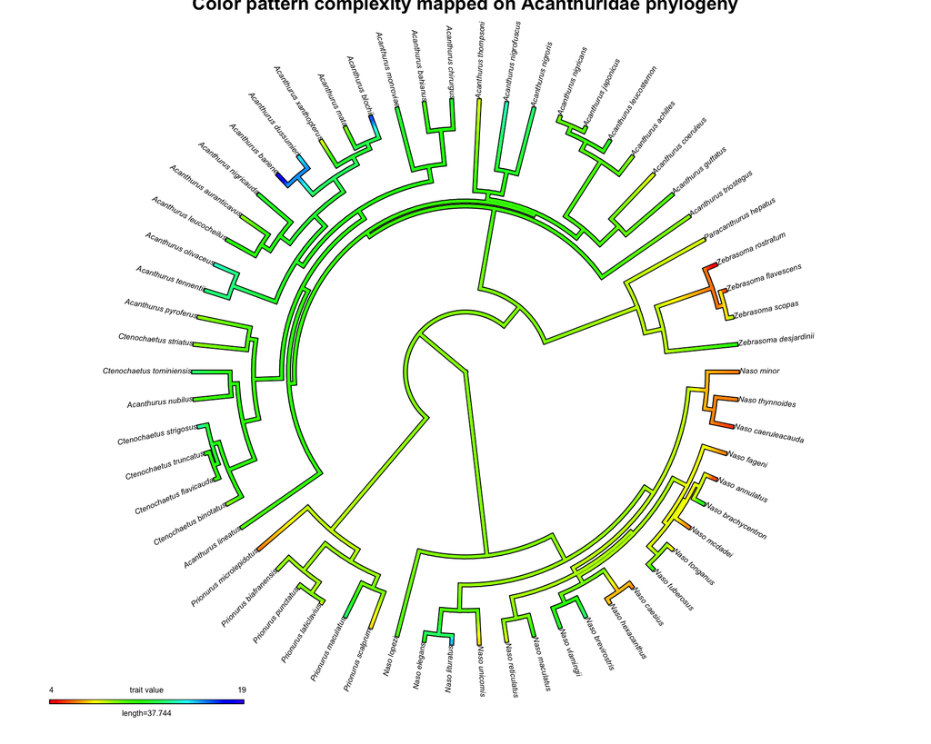

```r
# Create a named vector — phytools requires names to match tip labels
pc <- tr$pattern_complexity
names(pc) <- tr$species

# Generate the contMap object
cm <- contMap(tree_matched, pc, plot = FALSE)

# Plot it as a fan tree
plot(cm, type = "fan", fsize = 0.5, lwd = 3,
     legend = 0.7 * max(nodeHeights(tree_matched)))
title("Color pattern complexity mapped on Acanthuridae phylogeny")
```

Save a PDF of the contMap. This is the figure you will submit as part of your deliverable:

```r
pdf("results/pattern-complexity-contmap.pdf", width = 10, height = 10)
plot(cm, type = "fan", fsize = 0.5, lwd = 3,
     legend = 0.7 * max(nodeHeights(tree_matched)))
title("Color pattern complexity mapped on Acanthuridae phylogeny")
dev.off()
```

**What to look for**

**Discussion question**

Look at your contMap. Can you identify one or two branches where pattern complexity appears to shift dramatically? What might have driven those shifts? (Think about habitat changes, shifts in social behavior, or changes in predation regime.)

## Section 6: Testing Phylogenetic Signal

Your contMap gives you a visual impression, but we need statistics to back it up. We will use two complementary tests.

### Blomberg’s K

Blomberg’s K compares the observed trait variance among species to the variance expected under **Brownian motion** (a model where traits drift randomly along the tree).

| K value | Interpretation |
| --- | --- |
| K = 1 | Trait matches Brownian motion exactly |
| K > 1 | Relatives are *more* similar than BM predicts (strong phylogenetic conservatism) |
| K < 1 | Relatives are *less* similar than BM predicts (trait is more labile, possibly driven by selection or convergence) |
| K near 0 | No relationship between the tree and the trait |

The **p-value** comes from a randomization test: the trait values are shuffled across the tips 1,000 times, and the observed K is compared to that null distribution. If p < 0.05, the signal is statistically significant.

```r
K_result <- phylosig(tree_matched, pc, method = "K", test = TRUE)
K_result
```

```
Phylogenetic signal K : 0.162505
P-value (based on 1000 randomizations) : 0.041
```

```r
cat("\n--- YOUR INTERPRETATION ---\n")
```

```
--- YOUR INTERPRETATION ---
```

```r
cat("Blomberg's K =", round(K_result$K, 3), "\n")
```

```
Blomberg's K = 0.163
```

```r
cat("p-value      =", round(K_result$P, 4), "\n")
```

```
p-value      = 0.041
```

```r
if (K_result$P < 0.05) {
  cat("Result: SIGNIFICANT phylogenetic signal.\n")
  cat("Closely related surgeonfishes DO have more similar color complexity.\n")
} else {
  cat("Result: No significant signal.\n")
  cat("Color complexity is NOT strongly predicted by relatedness.\n")
}
```

```
Result: SIGNIFICANT phylogenetic signal.
Closely related surgeonfishes DO have more similar color complexity.
```

**Fill in this interpretation template**

*“My Blomberg’s K value was _____, which means that closely related species are [more / less] similar in pattern complexity than expected under Brownian motion. This signal [is / is not] statistically significant (p = _____). This suggests that color pattern complexity in surgeonfishes [is / is not] phylogenetically conserved.”*

### Pagel’s lambda

Pagel’s lambda asks the same fundamental question but approaches it differently. Lambda transforms the tree’s internal branch lengths to find the degree of phylogenetic signal that best fits the data.

| Lambda value | Interpretation |
| --- | --- |
| Lambda = 1 | The tree perfectly predicts trait similarity (full signal) |
| Lambda = 0 | The tree is irrelevant — equivalent to a star phylogeny where all species are equally related |
| 0 < Lambda < 1 | Partial signal — some phylogenetic structure, but not as much as BM predicts |

```r
lambda_result <- phylosig(tree_matched, pc, method = "lambda", test = TRUE)
lambda_result
```

```
Phylogenetic signal lambda : 0.29401
logL(lambda) : -155.306
LR(lambda=0) : 5.54131
P-value (based on LR test) : 0.0185727
```

```r
cat("\nPagel's lambda =", round(lambda_result$lambda, 3), "\n")
```

```
Pagel's lambda = 0.294
```

```r
cat("p-value        =", round(lambda_result$P, 4), "\n")
```

```
p-value        = 0.0186
```

**Do K and lambda agree?** They often give slightly different values because they are sensitive to different aspects of the data. K is more sensitive to tip-level similarity, while lambda is more sensitive to deep phylogenetic structure. If both are significant, you can be confident that there is real phylogenetic signal.

## Section 7: Mapping a Discrete Trait — Trunk Marbling

So far we have worked with a continuous summary variable (pattern complexity). Now let’s look at a single, specific color pattern element: **trunk marbling**. This is the irregular, worm-like patterning on the body that connects directly to the **Turing patterns** we discussed in Lecture 12. Turing patterns arise from reaction-diffusion dynamics between activator and inhibitor molecules during development — the same process that produces leopard spots, zebra stripes, and the labyrinthine patterns on some surgeonfishes.

```r
marbling <- tr$Tr_marbling
names(marbling) <- tr$species

cat("Trunk marbling present:", sum(marbling), "of", length(marbling), "species\n")
```

```
Trunk marbling present: 17 of 62 species
```

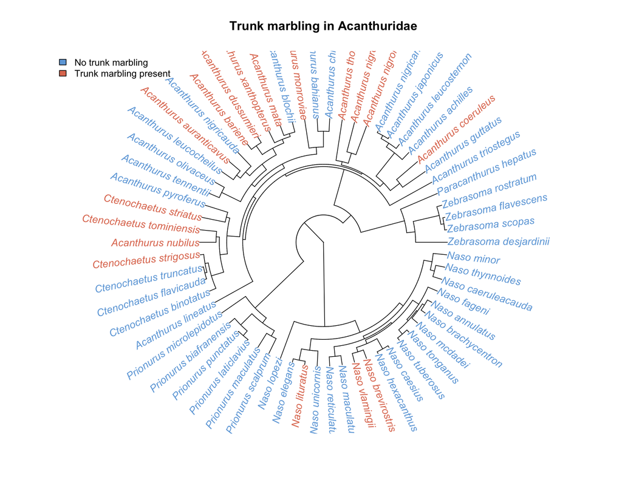

```r
# Color the tree tips by marbling presence
cols <- c("0" = "#6fa8dc", "1" = "#e07a5f")
plot(tree_matched, type = "fan", fsize = 0.45, lwd = 2.5,
     tip.color = cols[as.character(marbling[tree_matched$tip.label])])
legend("topleft",
       legend = c("No trunk marbling", "Trunk marbling present"),
       fill = c("#6fa8dc", "#e07a5f"), cex = 0.9, bty = "n")
title("Trunk marbling in Acanthuridae")
```

Save the trunk-marbling tree as a PDF:

```r
pdf("results/trunk-marbling-fan.pdf", width = 10, height = 10)
plot(tree_matched, type = "fan", fsize = 0.45, lwd = 2.5,
     tip.color = cols[as.character(marbling[tree_matched$tip.label])])
legend("topleft",
       legend = c("No trunk marbling", "Trunk marbling present"),
       fill = c("#6fa8dc", "#e07a5f"), cex = 0.9, bty = "n")
title("Trunk marbling in Acanthuridae")
dev.off()
```

**Discussion questions**

1. Does trunk marbling cluster on the tree, or is it scattered randomly across unrelated species?
2. Which genera seem to have the most trunk marbling? Which have none at all?
3. How many times do you think trunk marbling evolved independently?
4. Could this pattern be a Turing-generated trait? What would that imply about the developmental genetics underlying it?

## Section 8: Your Turn

Now it is your turn. Pick **one** trait from the list below and repeat the phylogenetic signal analysis.

### Trait options

| Trait column | What it is | Body region |
| --- | --- | --- |
| `H_marbling` | Irregular worm-like markings on the head | Head |
| `H_1_v_strip` | A single vertical stripe on the head | Head |
| `Ta_saddle` | Saddle-shaped dark marking on the tail | Tail |
| `Ta_colored_scalpel` | Distinctly colored caudal spine (the surgeonfish’s blade) | Tail |
| `Ta_eyespot` | Eyespot (ocellus) on the tail | Tail |
| `Tr_1_h_strip` | A single horizontal stripe on the trunk | Trunk |

### Steps

1. Create a named vector for your trait
2. Check how many species have it (for binary traits) or look at the range (for continuous ones)
3. Plot it on the tree — either with tip colors (binary) or contMap (continuous)
4. Run `phylosig()` with `method = "K"` and `test = TRUE`
5. Write down: What is your K? Is p < 0.05? What does it mean?

```r
# ---- YOUR CODE HERE ----

# Step 1: Create a named vector
# my_trait <- tr$__________
# names(my_trait) <- tr$species

# Step 2: How many species have this trait?
# cat("Trait present in:", sum(my_trait), "of", length(my_trait), "species\n")

# Step 3: Plot it on the tree (tip colors for a binary trait)
# cols <- c("0" = "#6fa8dc", "1" = "#e07a5f")
# plot(tree_matched, type = "fan", fsize = 0.45, lwd = 2.5,
#      tip.color = cols[as.character(my_trait[tree_matched$tip.label])])
# legend("topleft", legend = c("Absent", "Present"),
#        fill = c("#6fa8dc", "#e07a5f"), cex = 0.9, bty = "n")
# title("My chosen trait mapped on Acanthuridae")

# Step 4: Save a PDF copy of your tree
# (Change "my-trait" in the filename to your actual trait, e.g. "Ta-eyespot")
# pdf("results/my-trait-fan.pdf", width = 10, height = 10)
# plot(tree_matched, type = "fan", fsize = 0.45, lwd = 2.5,
#      tip.color = cols[as.character(my_trait[tree_matched$tip.label])])
# legend("topleft", legend = c("Absent", "Present"),
#        fill = c("#6fa8dc", "#e07a5f"), cex = 0.9, bty = "n")
# title("My chosen trait mapped on Acanthuridae")
# dev.off()

# Step 5: Test for phylogenetic signal
# K_mine <- phylosig(tree_matched, my_trait, method = "K", test = TRUE)
# K_mine

# Step 6: Interpret
# cat("K =", round(K_mine$K, 3), " p =", round(K_mine$P, 4), "\n")
```

## Part 2 — Your Group’s Three Species

In Part 1 you mapped color-pattern traits onto someone else’s clade (Acanthuridae). In Part 2 you’ll do the same kind of plot for **your own group’s fish family** — but with actual images of fish at the tips of the tree. By the end of this section you will:

1. log into the **FishView** server using your group’s code,
2. **pick three species from three different genera** in your family,
3. star (★) one exemplar image per species,
4. export a Part 2 bundle (3 images + a phylogeny), and
5. run an R script that renders the pruned tree with your three exemplar fish pinned at the tips.

The goal is simple. Once you see your three species sitting at the tips of an actual phylogeny, side-by-side with their photographs, you should be able to look at the image and ask: *do my species’ color patterns look more similar within a genus than across genera?*

### Step 1 — Log into FishView

The FishView server runs on the lab Mac mini and is only reachable from the **UCLA campus network or UCLA Bruin Secure VPN**.

1. Open `http://164.67.78.200:5052/` in your browser.
2. Enter your **group code** (see the table below) and your **first name**.
3. You’ll land on your group’s species dashboard.

| Group | Family | Code |
| --- | --- | --- |
| 1 | Balistoidea (triggerfishes) | `trigger-2026` |
| 2 | Pomacanthidae (angelfishes) | `angel-2026` |
| 3 | Scarinae (parrotfishes) | `parrot-2026` |
| 4 | Cirrhilabrini (fairy wrasses) | `fairy-2026` |
| 5 | Acanthuridae (surgeonfishes) | `tang-2026` |
| 6 | Hypsigenyinae (hogfishes) | `hog-2026` |
| 7 | Halichoerine (Coris-allies wrasses) | `coris-2026` |

**If the page won’t load**

You’re probably off-campus without VPN. Connect to **UCLA Bruin Secure VPN** first, then refresh. The server has no public DNS name — there is no way to reach it from outside UCLA’s network.

### Step 2 — Pick three species from three different genera

Why three different genera? Because the point of putting species on a tree is to show **phylogenetic spread**. If you pick three species of *Acanthurus*, you’ll get a tree that’s all one tiny twig — that’s not a comparative analysis, that’s three siblings. Picking three different genera guarantees your tree has real branching depth, and lets you see whether color patterns diverge as you move from genus to genus.

**Pick from the highlighted (🌳) species only**

Your dashboard now shows a **green 🌳 chip** next to species names that appear in your group’s phylogeny. **You must pick three highlighted species.** If you star an exemplar for a species that’s NOT in the tree, the Part 2 plot in Step 5 will silently skip it.

There’s also a **“🌳 Only species in the tree”** filter toggle in the controls row — flip it on to hide everything else and only see your candidates.

### Step 3 — Star (★) one exemplar image per species

For each of your three picked species:

1. Click the species name to open the review page.
2. Scroll through the available images. Exclude bad ones (back-facing fish, juveniles, weird angles) using the Exclude button.
3. Pick the one image that **best represents the typical adult color pattern** for that species, and click the ★ Exemplar radio button. That’s the image Part 2 will use.
4. Optionally set the Gestalt-K value (number of perceptually distinct colors, 2–10).
5. Hit “Save & Next species” or use the dropdown.

This is the same workflow you used last week — you’re just doing it for three species instead of all of them.

### Step 4 — Export the Part 2 bundle

Once all three species have a ★ exemplar marked, click the green **“Export Part 2 Bundle”** button at the top of the dashboard. The server packages everything into a ZIP file called `<family>-part2-bundle.zip`:

```
<family>-part2-bundle.zip
├── images/
│   ├── Genus_species_1.png
│   ├── Genus_species_2.png
│   └── Genus_species_3.png
├── <family>-tree.tre           ← Newick phylogeny for your family
├── picked_species.txt          ← the 3 species names
├── picked_tip_labels.txt       ← exact tree-tip labels (so R can prune)
└── README.txt
```

Unzip it into your demo folder under `data/my-fish/` (the folder structure must look like the tree above, with the ZIP’s contents inside `data/my-fish/`).

```r
# In RStudio: this assumes you've moved the ZIP into your demo folder
unzip("<family>-part2-bundle.zip", exdir = "data/my-fish")
list.files("data/my-fish", recursive = TRUE)
```

### Step 5 — Render the tree with your exemplar images at the tips

The R code below loads your three images and the pruned family tree, then plots the tree with each fish photo sitting at its corresponding tip. The tree comes from the same kind of phylogenetic analysis you ran in Part 1 — we just stripped it down to your three picked species.

```r
# Download the helper script (only needs to be done once per session)
dir.create("scripts", showWarnings = FALSE)
download.file(
  "https://michaelalfaro.github.io/eeb187-demos/scripts/part2-tree-with-images.R",
  "scripts/part2-tree-with-images.R"
)

# Load the helper that does the heavy lifting
source("scripts/part2-tree-with-images.R")

# Adjust `family` to your group's family (lowercase, no spaces) and the
# bundle directory to wherever you unzipped:
plot_part2(
  family     = "acanthuridae",         # e.g. cirrhilabrini, scarinae, halichoerine, hypsigenyinae
  bundle_dir = "data/my-fish",
  out_pdf    = "results/part2-tree-with-images.pdf"
)
```

What `plot_part2()` does, step by step:

1. **Reads** the Newick tree from `data/my-fish/<family>-tree.tre`.
2. **Prunes** it to just your three picked tip labels using `ape::keep.tip()` — the same function `drop.tip()` from Part 1, in reverse.
3. **Plots** the pruned tree with `ape::plot.phylo()`.
4. **Pulls** the tip x/y coordinates from `.PlotPhyloEnv` (a hidden environment that `plot.phylo` populates with the last plot’s layout).
5. **Places** each fish image at its tip using `rasterImage()` — this is base-R’s way to draw a raster (bitmap) at given coordinates.
6. **Labels** each image with the italicized species name underneath.
7. **Saves** the result as a vector PDF.

**What to look for**

Open `results/part2-tree-with-images.pdf` and put it next to your group’s three exemplar photos. Then ask:

- Are the **two species in the same genus** (if you happened to pick two from the same genus) more similar in pattern than the **outgroup species**?
- Do **closely related species** (joined by a deeper branch) look like obvious sister-species in terms of color, or do they look completely different?
- Are any of the patterns from Part 1 (stripes, bars, eyespots, marbling) shared across all three of your tips? Across just two? Across none?

**Discussion question**

In a single sentence: do your three species’ color patterns appear **conserved** along the phylogeny, or do they look like **independent paint jobs** with no obvious phylogenetic structure? Write the answer down — you’ll need it for the Deliverable.

### About your group’s tree

All seven groups now have a phylogeny in this demo release. Tree sources:

| Group | Family | Tree source | Tips |
| --- | --- | --- | --- |
| 1 | Balistoidea (triggerfishes + filefishes) | Fish Tree of Life (Rabosky et al.) — Balistidae + Monacanthidae combined | 83 |
| 2 | Pomacanthidae (angelfishes) | Dryad BEAST tree, doi.org/10.5061/dryad.r4xgxd2n4 | 56 |
| 3 | Scarinae (parrotfishes) | Brownstein et al. 2025 labrid backbone | 79 |
| 4 | Cirrhilabrini (fairy/flasher wrasses) | Brownstein et al. 2025 labrid backbone | 58 |
| 5 | Acanthuridae (surgeonfishes) | Frederich et al. 2026 | 65 |
| 6 | Hypsigenyinae (hogfishes) | Brownstein backbone (pruned subtree) | 38 |
| 7 | Halichoerine (rainbow + razor wrasses) | Brownstein backbone (pruned subtree) | 140 |

If your dashboard shows zero highlighted species, ask Rosamari to verify the server picked up the latest tree-species data — the green 🌳 chip must be visible on at least some species cards before you can do Step 2.

**If `plot_part2()` says “fewer than 2 of your picked tips were found”**

This usually means you picked a species that isn’t in the highlighted list. Go back to the dashboard, turn on the “🌳 Only species in the tree” filter, and re-pick three highlighted species. Then re-export the bundle and re-run.

## Deliverable

Submit the following on BruinLearn by **Friday May 22 at 11:59 PM**:

1. **`results/pattern-complexity-contmap.pdf`** from Section 5 (the colored fan tree).
2. **Your K and lambda values** with a one-sentence interpretation of each (use the template from Section 6).
3. **Your “Your Turn” results:** which trait you chose, K value, p-value, and your `results/my-trait-fan.pdf` (renamed to match your trait).
4. **One paragraph** (4–6 sentences) answering the question: **“Is color pattern diversity phylogenetically conserved in surgeonfishes?”** Your answer should be nuanced — some traits may show signal while others do not. Why might that be?
5. **Part 2: `results/part2-tree-with-images.pdf`** — the pruned tree with your three group exemplars at the tips.
6. **Part 2 interpretation (2 sentences):** *Do your three species’ color patterns appear conserved within your family’s phylogeny, or do they look randomly distributed?* Use what you see in your figure as evidence.

**Where are your files?**

Everything you generated today lives in your `results/` folder:

```
results/
├── acanthuridae-tree-rectangular.pdf
├── acanthuridae-tree-fan.pdf
├── pattern-complexity-histogram.pdf
├── pattern-complexity-contmap.pdf
├── trunk-marbling-fan.pdf
├── my-trait-fan.pdf                 ← yours from Section 8
└── part2-tree-with-images.pdf       ← Part 2, your group's three exemplars
```

If a file is missing, scroll back to the corresponding chunk and re-run it — the `dev.off()` line is what actually writes the PDF to disk. If a PDF is empty or won’t open, you likely forgot `dev.off()` and need to re-run the chunk from scratch.

## Citations

Tree and color pattern data: Frédérich, B., Mittelheiser, L., Gillet, A., Hodge, J. R., Laudet, V., & Dornburg, A. (2026). Rapid and repeated evolution of pigmentation patterns in reef fishes. *BMC Biology*, *24*(46). [DOI](https://doi.org/10.1186/s12915-026-02544-4) · PDF (open-access, CC BY-NC-ND)

See also: Brownstein, C. D., et al. (2025). Phylogenomics establishes an Early Miocene reconstruction of reef vertebrate diversity. *Science Advances*, 11, eadu6149.

## Next: Part 2 — your group’s family

Once you’ve finished the R-based exploration above, head over to the FishView server to do the per-image review that produces the input bundle for your group’s tree-with-photos figure.

**Walkthrough →** Demo 7 Part 2